# 2 Functions in Julia

A notebook for this material: ipynb

## 2.1 Introduction

We see in this section how to easily create mathematical functions in `Julia`. In the following sections we begin to do things with functions, such as graphing functions with `Julia`.

We begin by loading some packages:[^1]

```julia
using MTH229   # miscellaneous functions provided for a MTH 229 class
using Plots    # a package to provide ability to make plots
plotly()       # a selection of an interactive means to render plots
```

Once the environment is set up, for basic things, creating a new function and plotting it is as familiar as the following:

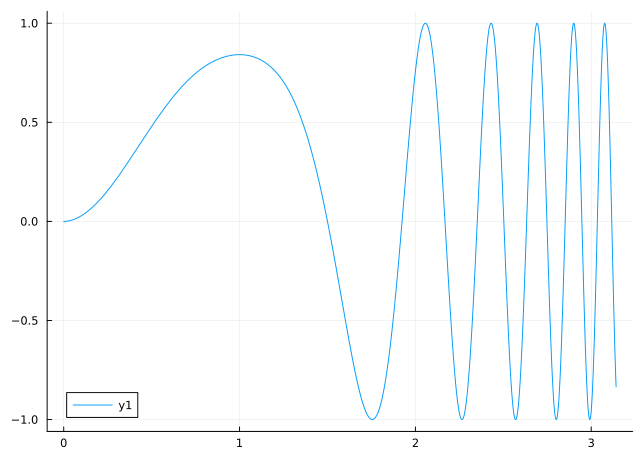

```julia
f(x) = sin(3x^2 - 2x^3)
plot(f, 0, pi)
```

In the above, the first line defines a function—using the same notation used in mathematics; the second plots in a stratightforward manner only expecting the user to specify a function (by name) and a domain to plot over.

Really, you’d be hard pressed to make this any shorter or more familiar. Of course, not everything is this easy so there are still things to learn, but keep in mind that 90% of what we want to do in these projects is really this straightforward.

Mathematically, a function can be viewed in many different ways. An abstract means is to think of a function as a mapping, assigning to each $x$ value in the function’s domain, a corresponding $y$ value in the function’s range. With computer languages, such as `Julia`, the same holds, though there may be more than one argument to the function and with `Julia` the number of arguments and type of each argument are consulted to see exactly which function (technically method) is to be called.

Here we don’t work abstractly though. For a mathematical function (real-valued function of a single variable, $f: \mathbb{R} \rightarrow \mathbb{R}$), we typically just have some rule for what the function will do to $x$ to produce $y$, such as

$$f(x) = \sin(x) - \cos(x).$$

In `Julia` there are a few different ways to define a function, we start with the most natural one which makes it very simple to work with such functions.

## 2.2 Mathematical functions

Real-valued functions ($f: \mathbb{R} \rightarrow \mathbb{R}$) are often described in terms of elementary types of functions such as polynomial, trigonometric, or exponential. We give examples of each in the following.

## 2.3 Polynomials and related functions

One of the most basic families of functions are the polynomial functions, which include as special cases the very familiar constant functions, linear functions and quadratic functions.

Let’s look at the familiar *linear* function to convert Fahrenheit into Celsius:

$$f(x) = 5/9 \cdot (x - 32).$$

That is we subtract $32$ then multiply by $5/9$

We can easily turn this into a function, simply by replacing the mathematical notation $\cdot$ with `*`:

```julia
f(x) = (5/9) * (x - 32)
```

```
f (generic function with 1 method)
```

This defines a function object `f`. To evaluate `f` for a given value of $x$ we simply use the familiar mathematical notation. Here we see what Celsius is for “normal” body temperature:

```julia
f(98.6)
```

```
37.0
```

And the Celsius equivalent to the standard boiling point:

```julia
f(212)
```

```
100.0
```

**NoteAlert**

We have three *different* things we do with functions:

- **Defining a function**, as above, can be done with the same syntax as mathematics. The function name with parentheses surrounds any arguments, an equal sign to indicate a *definition*, and a rule on the right of the equals sign, indicating what becomes of the arguments.
- **Calling a function** Evaluating a function for a given value is also known in programming languages as “calling” `f`. Again, the `Julia` syntax follows the mathematical notation: the function name, with the *values* to define the function at enclosed in parentheses.
- **Referring to a function** A function in `Julia` has a name, in the above this is just `f` (no parentheses, and definitely not `f(x)`.)

Though a function in `Julia` is typically *generic* and has different methods depending on the various inputs, this is a detail we don’t need to consider in these notes.

A familiar example from physics which models the height of a projectile is

$$h(t) = -\frac{1}{2}g \cdot t^2 + v_0\cdot t + x_0$$

If we take $g=32$ and $v_0 = 1$ and $x_0 = 100$, we can quickly write a `Julia` function:

```julia
h(t) = -(1/2)*32 * t^2 + t + 100
```

```
h (generic function with 1 method)
```

If this models the height of an object thrown upwards with a certain velocity from a certain height, what is this height when $t=2$?

```julia
h(2)
```

```
38.0
```

### 2.3.1 Numeric literals

`Julia` provides the familiar notation above for simple functions. In fact, for polynomials with numeric coefficients, one can even skip using `*` for multiplication:

```julia
g(x) = 2x^2 - 3x + 2
g(2)
```

```
4
```

The convention is that when variables are immediately preceded by a numeric literal (and by immediately it is meant no spaces are in between) `Julia` will assume multiplication is intended.

Implicit multiplication can also be used when simple parentheses are involved:

```julia
k(x) = 2(x - 1)^2 + 3(x+1)
```

```
k (generic function with 1 method)
```

But implicit multiplication won’t work with expressions such as `(x+1)(x-1)`, as `Julia` will then think the first parenthetical pair is a function and try to call it with a value of `x-1` typically resulting in a `MethodError` and mention of something not being “callable”.

**NoteImplicit multiplication is not recommended**

The precedence of *implicit multiplication* is **different** from explicit multiplication. While convenient, this can cause confusion while learning. (The expressions `1/2x` and `1/2*x` are **not** the same, as the first evaluates `2x` before the division.) As such we recommend against the use of implicit multiplication at the outset.

#### Example: Equations versus functions

Mathematically we tend to blur the distinction between the equation

$$y = 5/9 \cdot (x - 32)$$

and the function

$$f(x) = 5/9 \cdot (x - 32)$$

As the graph of the function $f(x)$ is the same as the graph of the equation $y=f(x)$. There is a distinction in `Julia` as these commands

```julia
x = -40
y = 5/9 * (x - 32)
```

```
-40.0
```

will evaluate the righthand side with the value of `x` bound at the time of assignment to `y`, whereas

```julia
f(x) = 5/9 * (x - 32)
f(72)               ## room temperature
```

```
22.22222222222222
```

will create a function which is called with a value of `x` at a later time. So the value of `x` defined when the function is created is not important here—`x` is passed in as an argument.

These notes almost always use functions not expressions, so becoming familiar with functions is necessary.

### 2.3.2 Rational functions

Rational functions are simply ratios of polynomial functions. Defining them is straightforward. For example.

$$f(x) = \frac{x^2 - 2}{x - 2}$$

becomes

```julia
f(x) = (x^2 - 2) / (x-2)
```

```
f (generic function with 1 method)
```

**NoteRemember parentheses!**

Here, as with your calculator, it is important to remember to use parentheses around the top and bottom expressions, as otherwise the division operator will have higher precedence than the subtraction operators.

Mathematically, the horizontal bar in division implies grouping of the top and bottom. Where as the `/` operation does not. (It doesn’t in mathematics either.) so mentally be prepared to do something like this:

$$\frac{\cdots}{\cdots} \Rightarrow \text{ ( ⋯ ) / ( ⋯ ) }$$

### 2.3.3 Other powers

While polynomials use non-negative integer coefficients for the powers, functions with other powers are, of course, possible. The `^` operator is used in general for powers, and the `sqrt` and `cbrt` offer an alternative.

So, this

$$f(x) = \sqrt{x} + x^{1/3} + x^{1/4}$$

can become:

```julia
f(x) = sqrt(x) + cbrt(x) + x^(1/4)
```

```
f (generic function with 1 method)
```

For the fractional power, this shows the required parentheses around `(1/4)` to ensure that division occurs before the higher-precedence power operation (compare `2^1/4` to `2^(1/4)`).

**Note`cbrt(x)` is not *always* `x^(1/3)`**

In math we are used to turning $\sqrt[n]{x}$ into $x^{1/n}$. In `Julia` that can bump into problems when `x` is negative. The `cbrt` function works with negative numbers to return a negative number, whereas `x^(1/3)` will error when `x` is negative. The issue is $x^y$ might need a complex number to represent the answer for *certain* values of $y$, and `Julia` doesn’t specialize its return value based on the value of `y`, but on the type of the value of `y`, in this case just throwing an error as some values of `y` would need complex numbers to represent the answer. (Starting with a complex number for `x` won’t error.)

## 2.4 Common functions

Of course `Julia` has readily available all the usual built-in functions found on a scientific calculator, and many more. See the section on [mathematical operations and functions](https://docs.julialang.org/en/v1/manual/mathematical-operations/#Arithmetic-Operators) of the official `Julia` documentation. In the following, we show how to translate some basic math functions into `Julia` functions:

### 2.4.1 Trigonometric functions

$$f(x) = \cos(x) - \sin^2(x)$$

becomes

```julia
f(x) = cos(x) - sin(x)^2
```

```
f (generic function with 1 method)
```

**NoteAbout exponents and functions…**

The conversion from the commonly written form ($\sin^2(x)$) to the far less ambiguous $\sin(x)^2$ is very important. This is necessary with `Julia`—as it is with calculators—as there is no function `sin^2`. In Julia, squaring is done on values—not functions, like `sin`. (And most likely squaring of a function is more likely to be composition, which is not the usage here.) So, to have success, learn to drop the notations $\sin^2(x)$ or for the arc sine function $\sin^{-1}(x)$. These shortcuts are best left in the age when mathematics was done just on paper.

**NoteDegrees, not radians**

If you want to work in degrees you can do so with the degree-based trigonometric functions, which follow the same naming pattern save a trailing “d”:

```julia
fd(x) = cosd(x) - sind(x)^2
```

```
fd (generic function with 1 method)
```

To keep the number of functions to know small, these functions are avoided in the following, rather, when needed, converting from degrees to radians through multiplication by `pi/180` is used.

### 2.4.2 Inverse trigonometric functions

A mathematical definition like

$$f(x) = 2\tan^{-1}\left(\frac{\sqrt{1 - x^2}}{1 + x}\right)$$

becomes

```julia
f(x) = 2atan( sqrt(1-x^2) / (1 + x) )
```

```
f (generic function with 1 method)
```

This particular function is just an alternative expression for the arc cosine (mathematically $\cos^{-1}$ but in `Julia` `acos`) using the arctan function, as seen here:

```julia
f(.5) - acos(.5) ## nearly 0
```

```
-2.220446049250313e-16
```

The exponent in the inverse trigonometric functions is *just* mathematical notation for the longer expression “arctan” or “arccos”. (It definitely is not a reciprocal.) The `Julia` functions—like most all computer languages—abbreviate these names to `atan`, `acos` or `asin`.

### 2.4.3 Exponential function

The math function

$$f(x) = e^{-\frac{1}{2}x^2}$$

Can be expressed as

```julia
f(x) = e^(-(1/2)*x^2)
```

```
f (generic function with 1 method)
```

The value of $e$ is built-in to `Julia`, but not immediately available. It is exposed by the `MTH229` package, so the above will work as long as that package has been loaded. But `e` is a convenient variable name, so `e` can be inadvertently redefined. As such, it is a safer practice to use the `exp` function, as in:

```julia
f(x) = exp(-(1/2)*x^2)
```

```
f (generic function with 1 method)
```

There isn’t much difference in use, but don’t try to do both at once, as in `exp^(-(1/2)*x^2)`!

[output not shown]

[output cut: 311 more lines]

Returning to our discussion of a line, suppose we have the function using multiple arguments to represent parameters:

```julia
point_slope(x, m, x1, y1) = y1 + m * (x - x1)
```

```
point_slope (generic function with 1 method)
```

In calculus, a *secant line* is related to a function, $f(x)$, and *two* points $(a,f(a))$ and $(b, f(b)).$ As two points determine a line, this is well defined. Suppose `f`, `a`, and `b` are specified, say by:

```julia
f(x) = x^2
a, b = 0, 1
```

```
(0, 1)
```

then we can create the secant line for this data as:

```julia
m = (f(b) - f(a)) / (b-a)
x1, y1 = a, f(a)  # or b, f(b) it doesn't matter
secant_line(x) = point_slope(x, m, x1, y1)
```

```
secant_line (generic function with 1 method)
```

This takes the values of `f`, `a`, and `b` (or the derived *parameters* `m`, `x1`, and `y1`) and creates a function of just `x`. This function can be called like any other function:

```julia
secant_line(3)
```

```
3.0
```

While the above construction is easy to understand, it is also a bit of a fragile construction, as the values of the parameters, `m`, `x1`, and `y1` are *global* variables derived from the basic inputs `f`, `a`, and `b`. As mentioned earlier, when `secant_line` is called the current values assigned to the global variables are used— not necessarily the same values as when `secant_line` is defined.

To be explicit about the values of the parameters being *fixed*, a different approach is typically used.

Below, we write a function to return an *anonymous function* with the values for the parameters fixed. In computer science language, we are creating a *closure*:

```julia
function Secant_Line(f, a, b)
    m = (f(b) - f(a)) / (b -a)
    x1, y1 = a, f(a)
    x -> point_slope(x, m, x1, y1)
end
```

```
Secant_Line (generic function with 1 method)
```

The same “`secant_line`” function would be generated through:

```julia
sl = Secant_Line(f, a, b)
```

```
#Secant_Line##0 (generic function with 1 method)
```

To see they are the same, let’s just call them at an arbitrary value of `x` and compare:

```julia
sl(3), secant_line(3)
```

```
(3.0, 3.0)
```

## 2.5 Note: “`sl`”—not “`sl(x)`”

The `Secant_Line` function above constructs and returns a *function*, so `sl` is a function object. We don’t need to write `sl(x)` on the *left-hand side*, as we do when we define a generic function or method through an expression of its arguments. This *can* be done, were the following usage employed:

```julia
sec_line(x) = Secant_Line(f, a, b)(x)
```

```
sec_line (generic function with 1 method)
```

but this is not recommended: it is a bit awkward to type, is inefficient, and—*most importantly*—uses *global* values for `a` and `b` each time it is called.

The `secant(f, a, b)` function in the `MTH229` package returns a function like `Secant_Line` that has a reminder of what it does when used:

```julia
f(x) = x^2
a, b = 0, 1
sl = secant(f, a, b)
```

```
Function of `x` to compute the secant line of `f` between `a` and `b`:
    f(a) + ((f(b)-f(a)) / (b-a)  * (x-a)
```

The `sl` object is a black-box function, but it can be used to identify the slope and the intercept of the secant line being represented.

For example, the intercept of a line (the $b$ in $y = m\cdot x + b$) is the value of the function when $x=0$ or:

```julia
b = sl(0)
```

```
0.0
```

The slope can be found by taking *any* two points, forming $(x_0, y_0)$ and $(x_1, y_1)$ and using the slope formula:

```julia
a, b = 2, 3
x0, y0 = a, sl(a)
x1, y1 = b, sl(b)
m = (y1 - y0) / (x1 - x0)
```

```
1.0
```

Or more directly, the two intermediate lines can be skipped:

```julia
m = (sl(b) - sl(a)) / (b - a)
```

```
1.0
```

##### Question

The `MTH229` package defines a related function `tangent(f, c)` to return a *function* which computes the tangent line to `f` at `c`:

```julia
f(x) = x^2
c = 1
tl = tangent(f, c)
```

```
Function of `x` to compute the tangent line of `f` at `c`:
    f(c) + f'(c) * (x-c)
```

For the line described by `tl`, compute:

- the $y$-intercept:

- the slope:

- the $x$-intercept:

**NotePartial function application**

A [partial function application](https://en.wikipedia.org/wiki/Partial_application) is related to the closure above. Consider our first example for a function representing the slope-intercept form using three arguments:

```
slope_intercept(x, m, b) = m * x + b
```

```
slope_intercept (generic function with 1 method)
```

For a fixed `m` and `b`, we can use the following style to create a function of `x` as follows:

```
SlopeIntercept(m, b) = x -> slope_intercept(x, m, b)
```

```
SlopeIntercept (generic function with 1 method)
```

When the function *returned* by `SlopeIntercept` is called, it uses the fixed values for `m` and `b`.

The pattern of fixing a value of a function is common enough that there are also functions `Base.Fix1` and `Base.Fix2` (and more generally `Base.Fix{N}`). Applied to a function `f(x,y)`, `Fix1` is used to create a function of `y` for a *fixed* `x`; `Fix2` to create a function of `x` for a fixed `y`. While the style of `SlopeIntercept` above, where an anonymous function is returned, is natural, the implementation of these two “fix” functions is more performant and their use appears often behind the scenes.

## 2.6 Practice

#### Question: transformations

Which of these function definitions corresponds to shifting the function `f` to the right by `c` units and up by `d` units with a default of $0$ and $0$:

`g(x; c=0, d=0) = d + f(x - c)`

`g(x; c=0, d=0) = c + d(f - x)`

`g(x; c=0, d=0) = c + f(x - d)`

`g(x; c=0, d=0) = f(c * (x - d))`

#### Question: transformations

Which of these definitions will lengthen the period of a periodic function $f$ by a factor of $c$, with a default of $1$?

`g(x; c=1) = c + f(x)`

`g(x; c=1) = f(x / c)`

`g(x; c=1) = f(c * x))`

`g(x; c=1) = c * f(x)`

#### Question: wavelet transform

The following transform of a function is at the core of wavelet theory:

```julia
g(t; a=1, b=0) = (1/sqrt(a)) * f((t - b)/a)
```

```
g (generic function with 1 method)
```

If $f(x) = \sin(x)/x$ and $a=2$ and $b=1$ compute $g(0, a=2, b=1)$.

#### Question

Let $g$ be defined by:

```julia
function g(x; theta=pi/4)
     a = 200*cos(theta)
     tan(theta)*x + (32/a)*x + 32*log((a-x)/a)
end
```

```
g (generic function with 1 method)
```

For `x` in 20, 25, 30, 35, 40, 45 degrees, what value will maximize `g(125, theta=x*pi/180)`?

#### Question

What anonymous function will compute $\sin(x^2)$?

`x -> sin^2(x)`

`x -> sin(x)^2`

`x -> sin(x^2)`

#### Question

What anonymous function of $x$ will return the polynomial $x^2 - 2x$:

`() -> x^2 - 2x`

`x ->x^2 - 2x`

`x^2 - 2x -> x`

#### Question

What does this function do?

```julia
function mystery(f)
   x -> -f(x)
end
```

```
mystery (generic function with 1 method)
```

It is a mystery

It returns a function whose graph is that of `f` reflected through the \(x\) axis

It returns a function whose graph is that of `f` reflected through the \(y\) axis

#### Question

What does this operator do?

```julia
function trim(f, c)
  x -> abs(f(x)) <= c ? f(x) : NaN
end
```

```
trim (generic function with 1 method)
```

It computes the slope of the secant line.

It produces an error.

It returns a function which has NaN values where `f` would be greater in value than `c`

## 2.7 Additional details

This section presents some additional details on writing functions in `Julia` that are here for informational purposes only.

### 2.7.1 Return values, tuples

As mentioned, the value returned by a function is either the last value executed or any value returned by `return`. For a typical real valued function $f$ this is usually just a number. Sometimes it is convenient to return more than one value. For this a *tuple* proves useful:

A *tuple* is a container for holding different objects at once. They are made quite simply by enclosing the values in parentheses:

```julia
(1, "one")
```

```
(1, "one")
```

Tuples have many uses, but here we want to focus on their use as return values. Here is a somewhat contrived example. Imagine you write a function to compute the value of $f(x) = x^x$, but you want to ensure $x$ is positive, as otherwise there will be an error. You can do this, where we return a value of `NaN` and a message when the user tries to use a negative number:

```julia
f(x) = x > 0 ?  (x^x, "") : (NaN, "You can't use non-positive numbers")
```

```
f (generic function with 1 method)
```

We include a message even when the value of $x$ is okay, as it is good practice –though not a requirement of `Julia`—to always return the same type of object, regardless the input.

A simple call would be:

```julia
f(-1)
```

```
(NaN, "You can't use non-positive numbers")
```

We get a tuple back. `Julia` makes working with tuple return values very easy. We can *destructure* them by simply placing two variable names on the left-hand side:

```julia
a, msg = f(-1)          # alternatively: (a, b) = f(-1)
```

```
(NaN, "You can't use non-positive numbers")
```

A less artificial example will be discussed later: the `quadgk` function which estimates the value of an integral. For this computation both the value and an estimated maximum error are of interest, so both are returned using a tuple.

### 2.7.2 Specializing functions by argument type

Typical functions here are real-valued functions of a single variable. The easiest way to use these is to just mimic the regular mathematical notation as much as possible. However, there are times where we want to be specific about what possible values a user can place into a function. For example, a naive function to compute the binomial coefficients,

$${ n \choose k } = \frac{n!}{(n-k)! k!},$$

can be specialized to just integer values with:

```julia
binom(n::Integer, k::Integer) = factorial(n)/(factorial(n-k) * factorial(k))
```

```
binom (generic function with 1 method)
```

The extra bit `::Integer` is called a *type annotation* and specializes `n` and `k` so that this function only is called when both `n` and `k` are of this type.

As defined, we can call our `binom` function as:

```julia
binom(10, 4)
```

```
210.0
```

But not as follows ($\pi$ is not an integer):

```julia
binom(10, pi)
```

```
MethodError: no method matching binom(::Int64, ::Irrational{:π})
The function `binom` exists, but no method is defined for this combination of argument types.

Closest candidates are:
  binom(::Integer, ::Integer)
   @ Main.Notebook ~/work/mth229.github.io/mth229.github.io/quarto/functions.qmd:1565

Stacktrace:
 [1] top-level scope
   @ ~/work/mth229.github.io/mth229.github.io/quarto/functions.qmd:1582
```

(The actual `binomial` function is much better than this, as it doesn’t divide a big number by a big number, which can cause real issues with loss of precision, though it does specialize to integers, and any sub-type. It also always returns an integer, whereas ours returns a floating-point value.)

Types in `Julia` are a more complicated matter than we want to get into here, but we do want to list the common types useful for basic calculus: `Function`, `Real`, `Integer`, `Rational`, `Complex`, and `Number` (real or complex).

Clearly the latter ones should nest, in that an object of type `Integer` should also be of type `Real`. This means when we specialize a mathematical function, it is enough to specify values of `Real`.

### 2.7.3 Expressions as functions

The `MTH229` package loads a small package, `SimpleExpressions`, which can be used to blur the distinction between an expression and a function. Later on, the `SymPy` package will be illustrated which allows this blurring and *much* more.

Consider the polynomial $p = 100 + 20x - 16x^2$. Polynomials can be viewed either as [a mathematical expression consisting of indeterminates](https://en.wikipedia.org/wiki/Polynomial) or as a polynomial function.

As an expression of indeterminates, polynomials can be algebraically combined, eg. added, multiplied, etc. They can be factored; in calculus integrated and differentiated.

As functions they can be evaluated; used as examples of continuous and differentiable functions; integrated and differentiated, etc.

Within `Julia` the distinction is important:

- *expressions* are immediately evaluated
- functions have their evaluation delayed until they are called

Unlike expressions, function’s can’t be added or subtracted without the effort of creating a new function, as previously illustrated.

To illustrate, without first setting a value for `x`, the expression below would error:

```julia
x = 2
p = 100 + 20x - 16x^2
```

```
76
```

As `2` is assigned to `x`, the value `2` is substituted in for the symbol `x` and the expression is immediately evaluated and assigned to `p`.

Contrast this with the definition as a polynomial function:

```julia
f(x) = 100 + 20x - 16x^2
```

```
f (generic function with 1 method)
```

The variable `x` need not be defined when `f` is defined, a value for the variable is assigned when the function is called. For example:

```julia
f(2)
```

```
76
```

The `SimpleExpressions` package allows the creation of one symbolic variable and optionally one symbolic parameter. These can be used in an expression as above. However, rather than being evaluated immediately in the expression, the evaluation steps involving the variable are queued up and deferred until a value is assigned.

The `@symbolic` macro is used to create the variable, which is then used within other expressions:[^2]

```julia
@symbolic x
p = 100 + 20x - 16x^2
```

```
100 + (20 * x) + (-1 * 16 * (x ^ 2))
```

This symbolic expression can be added and multiplied, as is typically done by hand:

```julia
q = (1 + 2p)*p^2
```

```
(1 + (2 * (100 + (20 * x) + (-1 * 16 * (x ^ 2))))) * ((100 + (20 * x) + (-1 * 16 * (x ^ 2))) ^ 2)
```

A new expression is returned and assigned to `q` above. These symbolic expressions are not simplified.[^3]

The expressions in `SimpleExpressions` are also functions[^4] and can be used where functions would be.

For example, we can easily call them:

```julia
p(2)
```

```
76
```

or

```julia
q(3)
```

```
8448
```

Importantly, these expressions can be passed in as functions to other functions. Skipping ahead a bit, we see that a simple expression can be used in place of a function when plotting:

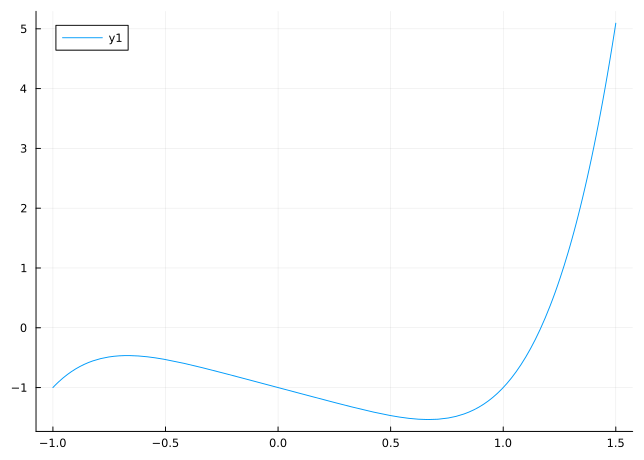

```julia
plot(x^5 - x - 1, -1, 1.5)  # x is symbolic; Plots is loaded
```

One final feature of simple expressions is they can also represent equations. This is done by separating the left and right hand sides with a `~`.

A plot recipe is defined, so plotting of these equations is straightforward and highlights the two sides as separate functions:

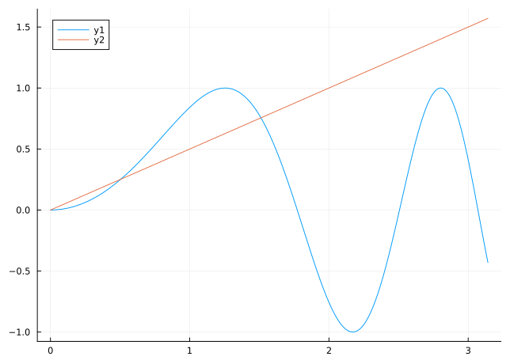

```julia
eqn = sin(x^2) ~ x/2

plot(eqn, 0, pi)
```

Again, skipping ahead, we see the three intersection points in $[0,\pi]$ can be identified with:[^5]

```julia
solve(eqn, 0, pi)
```

```
3-element Vector{Float64}:
 0.0
 0.505482272339305
 1.511542718555805
```

Finally, to show that having a parameter might be useful, what if the intersection points in terms of the slope of the line ($1/2$ above) was of interest? In the following we parameterize it and show how to substitute in a value for the parameter:

```julia
@symbolic x p
eqn1 = sin(x^2) ~ x/p
solve(eqn1(:, 3), 0, pi)
```

```
5-element Vector{Float64}:
 0.0
 0.3340259282913851
 1.6052940219459464
 2.7243212874268083
 2.857225258605647
```

As can be imagined, the number of intersection points depends on how flat the line is. This shows for `p=2` three intersection points, but for `p=3` five such.

The `@symbolic` macro treats the first symbol as a symbolic variable, the second (when given) as a symbolic parameter. The notation `eqn(:, 3)` substitutes `3` in for the symbolic parameter `p`, returning an equation in `x` that can be passed to the zero-finding function.

**NoteEnvironment of `Julia` when generated**

`Julia` version:

```julia
VERSION
```

```
v"1.12.6"
```

Packages and versions:

```julia
using Pkg
Pkg.status()
```

```
Status `~/work/mth229.github.io/mth229.github.io/Project.toml`
  [a2e0e22d] CalculusWithJulia v0.3.2
  [7073ff75] IJulia v1.34.4
  [b964fa9f] LaTeXStrings v1.4.0
  [ebaf19f5] MTH229 v0.3.2
  [91a5bcdd] Plots v1.41.6
  [f27b6e38] Polynomials v4.1.1
  [438e738f] PyCall v1.96.4
  [612c44de] QuizQuestions v0.3.27
  [295af30f] Revise v3.14.2
⌅ [f2b01f46] Roots v2.3.0
  [24249f21] SymPy v2.3.3
  [56ddb016] Logging v1.11.0
Info Packages marked with ⌅ have new versions available but compatibility constraints restrict them from upgrading. To see why use `status --outdated`
```

[^1]: Packages are a means to extend base `Julia`. There are thousands of add-on packages for `Julia`, but these notes basically use just the two here, which rely on a handful of other add-on packages.
[^2]: The `SymPy` package will be used later on in these notes. It too has symbolic variables, but those variables have much more flexibility and the `SymPy` package has many, many more features. `SimpleExpressions` sole purpose is very modest, just to make basic expressions of a single variable and optional parameter act like functions.
[^3]: Later, when `SymPy` is used for symbolic computations, some basic simplification happens automatically.
[^4]: The type holding a simple expression subtypes `Function` and has a “call” method defined to allow the expressions to have the same calling style as a function.
[^5]: The `solve` generic finds solutions to a problem. It is widely used within the `Julia` ecosystem, but not so much in these notes. The call `solve(f::Function, ...)` has too many different possible interpretations to privilege just one; to call a desired one, the function is typically wrapped into a distinguishing type. So, the use of `solve` here would be `solve(ZeroProblem(f,...),...)` which gets a bit verbose for this level, where a different name will suffice, as seen later. However, in this example, the `eqn` expression has a specific type, so `eqn` need not be wrapped into another special type.